# Chapter 2: Linear Models for Financial Time Series

This is note for Ruey S. Tsay’s R instruction on fincncial time series, chapter 2. For further knowledge on linear time series analysis, please refer to Tsay’s book financial analysis (2010).

In this chapter, Ruey introduced following models:

- Simple autoregressive model (AR)
- Simple moving average model (MA)
- Mixed autoregressive moving average model (ARMA)
- Unit-root models and unit-root test
- Exponential Smoothing
- Seasonal Models
- Regression models with time series errors
- Fractionally differenced models for long-range dependence

# 1 Stationary

## 1.1 Weak stationary

“Weak Stationary” is fundamental concept in financial time series analysis. Literally, it states that the log return of a certain stock or asset is around 0 over time, i.e. if the time span is divided into subperiods and the resulting sample mean of subperiods is close to 0.

The most significant property of a week stationary statistics variable is time-invariance.

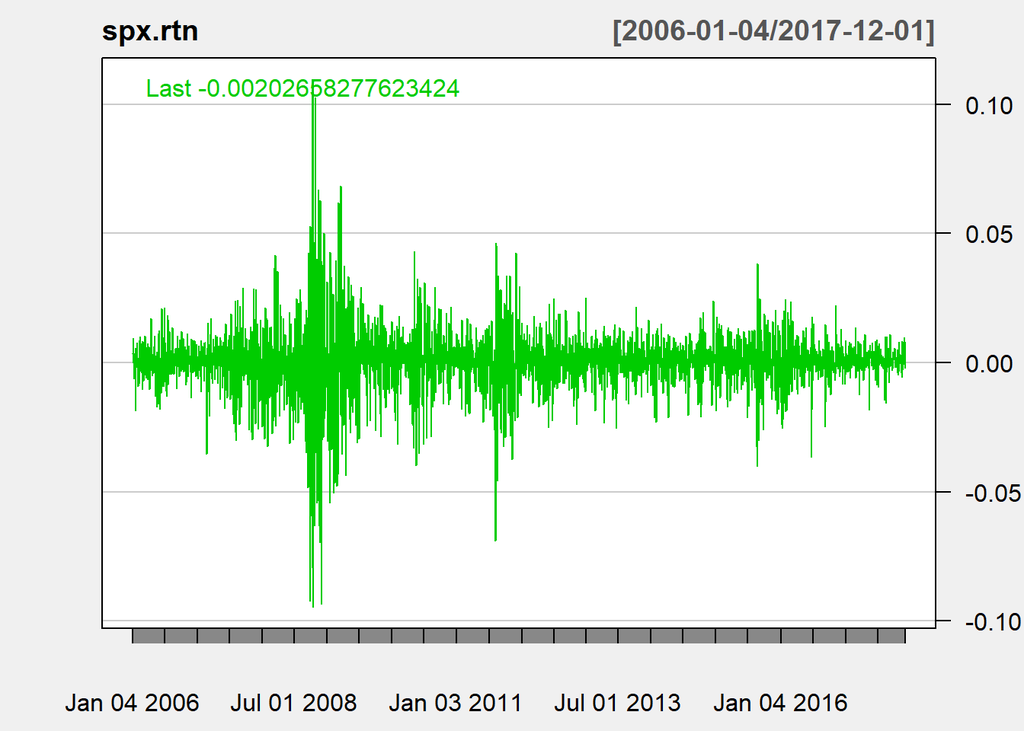

```r
library(quantmod)
spx <- getSymbols("^GSPC",from = "2006-01-01")
spx.rtn <- diff(log(GSPC$GSPC.Adjusted)) # Compute log returns
chartSeries(spx.rtn,theme="white")
```

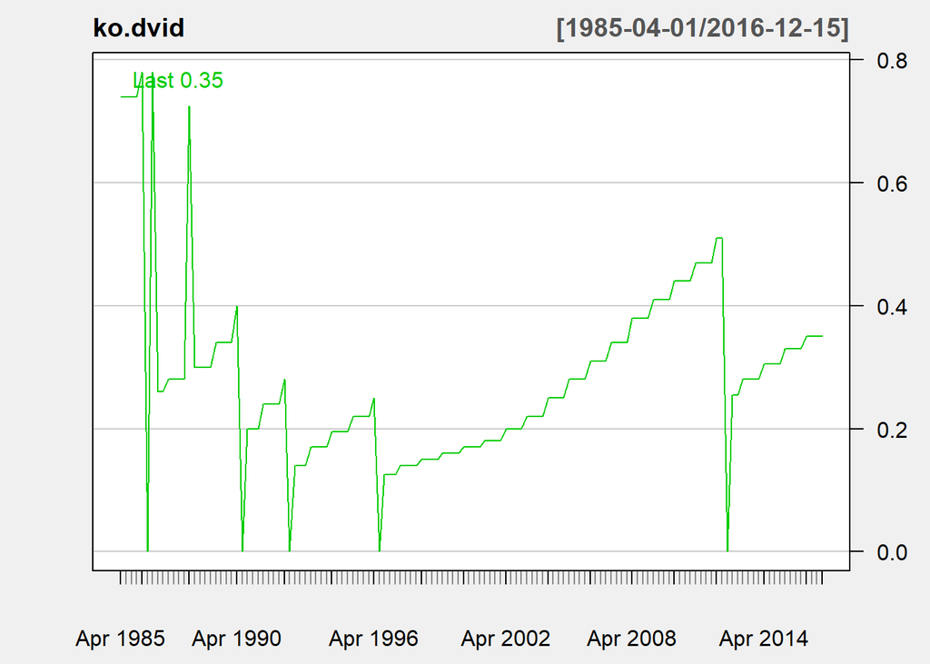

```r
library(xts)
library(lubridate)
library(quantmod)
ko <- read.csv("KO_1985-2010.csv")
ko.dvid <- na.omit(ko[, c(3,4)])
ko.dvid[, 1] <- ymd(ko.dvid[, 1])
ko.dvid <- xts(ko.dvid[,2], order.by = ko.dvid[,1])
chartSeries(ko.dvid, theme = "white")
```

This is the dividend payment of Coca Cola from 1985 to 2016, the date and payment is given by [WRDS](https://wrds-web.wharton.upenn.edu/wrds/index.cfm). If dividing the time span, we could see that the payment is not time invariant. The difference of each subperiod is significant.

Now we conclude some important properties of time series $x_t$:

1. The first 2 moment of $x_t$, i.e mean $\mu = \mathbb{E}(x_t)$ and variance $\gamma_0 = \mathbb{E}[(x_t - \mu)^2]$. Here $\mu, \gamma_0$ are not functions of $t$.
2. For given $k$, the lag-$k$ autocovariance of $x_t$ as $\gamma_k = Cov(x_t, x_{t-k})$.

   2.1. By Cauchy-Schwarz inequality, $\gamma_k$ exists and is time invariant, and this statistics variable show linear dependence between $x_t$ and $x_{t-k}$.

   2.2. $\gamma_k = \gamma_{-k}$, $\gamma_0 = Var(x_t)$.

# 2 Correlation and autocorrelation function

$$\rho_{x,y} = \frac{Cov(x,y)}{\sqrt{Var(x)\cdot Var(y)}}$$

And the estimation of $\rho_{x,y}$ is trivial.

## 2.1 Alternatives of traditional Pearson correlation

The most popular 2 alternatives: 1. Spearman’s rho – Spearman’s rank correlation, as is based on ranks of marginal variables. 2. Kendall’s tau – difference between concordance and discordance.
$$\tau = P[(X_1 - X_2)(Y_1 - Y_2) > 0] - P[(X_1 - X_2)(Y_1 - Y_2) < 0]$$
where $(X_1, Y_1), (X_2, Y_2)$ are iid continuous bivariate random variables.

```r
cor(sp5,ibm,method='spearman')
cor(sp5,ibm,method='kendall')
```

## 2.2 Autocorrelation Function (ACF)

Assump $x_t$ is weakly stationary, lag-$k$ autocorrelation $\rho_k$ of $x_t$ is
$$\rho_k = \frac{Cov(x_t, x_{t-k})}{\sqrt{Var(x_t) Var(x_{t-k})}} = \frac{Cov(x_t, x_{t-k})}{Var(x_t)} = \frac{\gamma_k}{\gamma_0}$$

Similar to $\gamma_k$, $\rho_0 = 1, \rho_k = \rho_{-k}$ and $-1 \leq \rho_k \leq 1$. Here $\{\rho_k\}_{k=0,1\dots}$ is ACF of $x_t$.

If $\rho_k = 0$ for $\forall k>0$, $x_t$ is not serially correlated.

For given $\{x_t\}_{t=1,\dots,T}$, then
$$\begin{align*}
\bar{x} &= \frac{1}{T}\sum^{T}_{1} x_t\\
\hat{\rho_0} &= \frac{\sum_{t=2}^{T}(x_t-\bar{x})(x_{t-1}-\bar{x})}{\sum_{t=1}^{T}(x_t - \bar{x})^2}\\
\hat{\rho_k} &= \frac{\sum_{t=k+1}^{T}(x_t-\bar{x})(x_{t-k}-\bar{x})}{\sum_{t=1}^{T}(x_t - \bar{x})^2} \quad 0\leq k<T-1
\end{align*}$$

If $\{x_t\}$ iid with $\mathbb{E}[x_t^2]<\infty$. Then
$$\hat{\rho_k} \longrightarrow \mathbf{N}[0, \frac{1}{T} ] \quad \text{asymptotically}$$

For more weaker case, $x_t$ weakly stationary and has the form (linear time series)
$$x_t = \mu + \sum_{i=0}^{q} \psi_i a_{t-i}$$
$\psi_0 =1$, $\{a_i\}$ iid and with mean 0, then
$$\hat{\rho_k} \longrightarrow \mathbf{N}[0, \frac{1+2\sum_{i=1}^{k-1}\rho_i^2}{T} ] \quad \text{asymptotically}$$

```r
da = read.table("m-dec12910.txt",header=T)
head(da)
```

```
##       date      dec1      dec2      dec9    dec10
## 1 19670131  0.068568  0.080373  0.180843 0.211806
## 2 19670228  0.008735  0.011044  0.048767 0.064911
## 3 19670331  0.039698  0.035364  0.067494 0.068904
## 4 19670428  0.044030  0.037541  0.040785 0.044602
## 5 19670531 -0.050631 -0.036233 -0.002191 0.000295
## 6 19670630  0.014998  0.018870  0.102075 0.118678
```

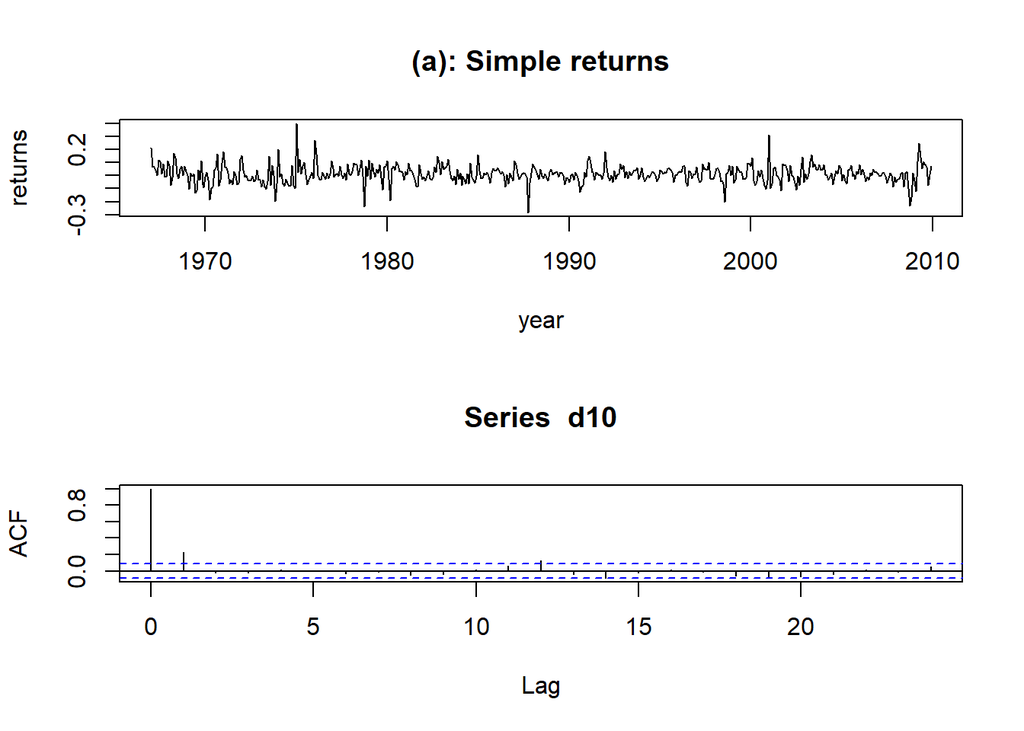

```r
d10 = da$dec10  # select the Decile 10 returns
dec10 = ts(d10, frequency = 12, start = c(1967,1))
par(mfcol = c(2, 1))
plot(dec10, xlab='year', ylab = 'returns')
title(main = '(a): Simple returns')
acf(d10, lag = 24) # command to obtain sample ACF of the data
```

Here on acf plot, the 2 dashed line is the boundary of 2 standard error $\pm 2/\sqrt{T}$, i.e 95% CI for individual acf.

## 2.3 Test ACF

### 2.3.1 Test individual ACF

For given $k$, we have hypos to test:

1. $H_0 : \rho_k = 0$,
2. $H_1 : \rho_k \neq 0$

And the test statistics is
$$t-ratio = \frac{\hat{\rho_k}}{\sqrt{(1+2\sum_{i=1}^{k-1}\hat{\rho}_i^2)/T}} = \frac{\hat{\rho_k} \sqrt{T}}{\sqrt{1+2\sum_{i=1}^{k-1}\hat{\rho}_i^2}}$$

For most packages in `R`, they use
$$t-ratio = \frac{\hat{\rho_k}}{\sqrt{1/T}} = \hat{\rho_k}\sqrt{T}$$

If $\{x_t\}$ a stationary Gussian Series ($\exists N, x_n = 0, \forall n>N$), with $\rho_j =0$ for $j>k$, then
$$t-ratio \longrightarrow \mathbf{N}[0,1] \quad \text{as} \ {} T \rightarrow \infty$$

This means when testing hypo, just compare $|t-ratio|$ with $\mathbb{Z}_{\alpha/2} = 1.96$.

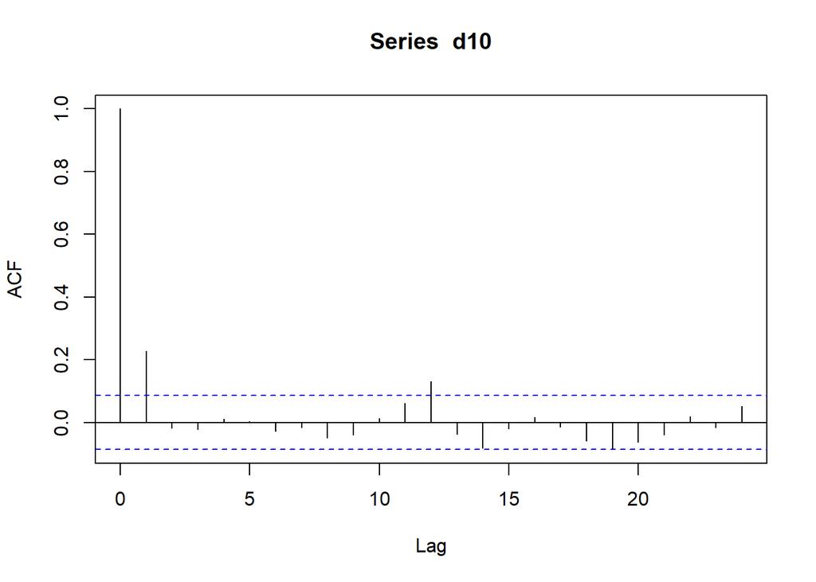

```r
f1=acf(d10,lag=24)
```

```r
f1$acf
```

```
## , , 1
##
##               [,1]
##  [1,]  1.000000000
##  [2,]  0.227386585
##  [3,] -0.019026447
##  [4,] -0.021258247
##  [5,]  0.011011345
##  [6,]  0.002676057
##  [7,] -0.027654887
##  [8,] -0.016910608
##  [9,] -0.049183690
## [10,] -0.039617756
## [11,]  0.013265549
## [12,]  0.061013220
## [13,]  0.130411045
## [14,] -0.036881195
## [15,] -0.082462743
## [16,] -0.020950139
## [17,]  0.016726386
## [18,] -0.013961209
## [19,] -0.059422809
## [20,] -0.082246074
## [21,] -0.063641596
## [22,] -0.039858376
## [23,]  0.017770989
## [24,] -0.015413528
## [25,]  0.052212082
```

```r
tt=f1$acf[13]*sqrt(516)
tt
```

```
## [1] 2.962369
```

### 2.3.2 Portmanteau Test

This is the fun part, like what we did in multivariate regression and test all or part of coefficients in model simutaneously.

In fact, a linear (pay attention to our linearity assumption) time series model can be characterized by its ACF. And by making use of sample ACF, we could specify the dependence of the data.

Now we give the hypos of jointly test:

$$H_0 : \rho_0 = \rho_1 = ... = \rho_m = 0$$
$$H_1 : \rho_i \neq 0 \quad \text{for some}\quad i \in \{0,1,2...,m\}$$

The test statistic is constructed by Box and Pierce (1970):
$$Q_{*}(m) = T \sum_{l = 1}^{m} \hat{\rho}_l^2$$

If $\{ x_t \}$ is iid,
$$Q_{*}(m) \longrightarrow \chi^2(m) \quad \text{asymptotically}$$

We have the modified $Q_{*}(m)$ statistic to increase the power of test for finite sample:

$$Q(m) = T(T+2) \sum_{l=1}^{m} \frac{\hat{\rho}^2_l}{T-l}$$

Comparing with $\chi^2_{\alpha}$, we could decide to reject $H_0$.

```r
# Ljung-Box Q statistics
da=read.table("m-ibmsp6709.txt",header=T)
ibm=da$ibm
lnibm=log(ibm+1) # Transfer to log returns
Box.test(ibm,lag=12,type='Ljung')
```

```
##
##  Box-Ljung test
##
## data:  ibm
## X-squared = 7.5666, df = 12, p-value = 0.818
```

```r
Box.test(lnibm,lag=12,type='Ljung')
```

```
##
##  Box-Ljung test
##
## data:  lnibm
## X-squared = 7.4042, df = 12, p-value = 0.8298
```

Simulation study suggests that $m \approx ln(T)$ provides better power performance.

In `CAPM`, we want that $\{x_t\}$ is not predictable and have no autocorrelations. By $Q$, we have the tool to test efficiency of market.

## 2.4 White noise

**Def**: A time series $\{x_t\}$ whose variables are iid and have finite mean and variance. For example, Gussian white nosie $\{x_t\} \sim \mathbb{N}[0,\sigma^2]$

White noise’s ACFs are 0. In practice, we could see sample with ACFs = 0 as white nosie.

## 2.5 Linear Time series

**Def** a time series is linear if it’s a linear combination of white series and its mean
$$x_t = \mu + \sum^{\infty}_{i=0} \psi_i e_{t-i}$$
with $\psi_0 = 1, \{e_k\} \sim \mathbb{N}[0,\sigma^2]$. It’s trivial to see $x_t$’s mean and variance. Here we could see $e_t$ as the new info at time $t$.

Note that the stationary time series requires that $Var(x_t) < \infty$, i.e.
$$\sum^{\infty}_{i=0} \psi_{i}^2 <\infty$$
This means the influence of remote $e_k$ from time $t$ vanishes.

The lag-$l$ autocovariance (use the iid of $e_k$)
$$\begin{align*}
\gamma_l &= Cov(x_t, x_{t-l}) \\
&= \mathbf{E} \big[ (\sum^{\infty}_{i=0} \psi_i e_{t-i})(\sum^{\infty}_{j=0} \psi_j e_{t-i-l})\Big] \\
&= \mathbf{E}(\sum_{i,j=0}^{\infty} \psi_i \psi_j e_{t-i} e_{t-j-l})\\
&= \sigma^2 \sum_{j=0}^{\infty} \psi_j \psi_{j+l}
\end{align*}$$